# Survival Analysis: Acute-on-Chronic Kidney Disease in Cats

#### 5.2.4 Batch test and performance summary for logistic regression classifier

```
Training and Test Scores Results for 500 days survival with LogisticRegression():
```

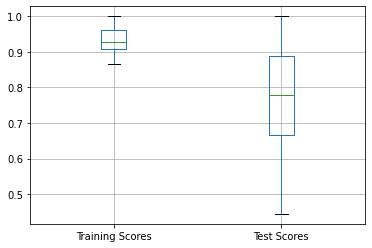

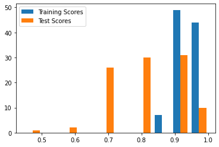

```
Confusion matrix:
[[550 129]
 [ 53 168]]
Classification report:
              precision    recall  f1-score   support

         0.0       0.91      0.81      0.86       679
         1.0       0.57      0.76      0.65       221

    accuracy                           0.80       900
   macro avg       0.74      0.79      0.75       900
weighted avg       0.83      0.80      0.81       900
```

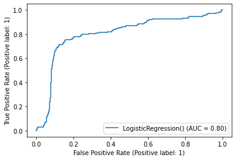

```python
_ = batch_test_classifier(features_500_days_with_imputed_values, target_500_days, 0.2, LogisticRegression(), '500 days survival')
```

```
Training and Test Scores Results for 100 days survival with LogisticRegression():
```

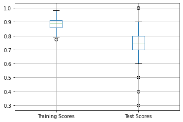

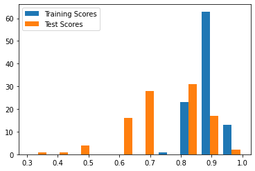

```
Confusion matrix:
[[507 149]
 [111 233]]
Classification report:
              precision    recall  f1-score   support

           0       0.82      0.77      0.80       656
           1       0.61      0.68      0.64       344

    accuracy                           0.74      1000
   macro avg       0.72      0.73      0.72      1000
weighted avg       0.75      0.74      0.74      1000
```

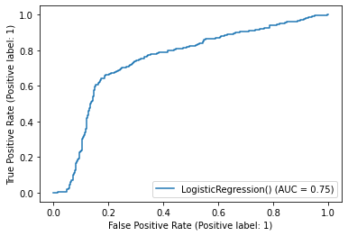

```python
_ = batch_test_classifier(features_100_days_with_imputed_values, target_100_days, 0.2, LogisticRegression(), '100 days survival')
```

## 6. Conclusions, discussion, and future work

On test sets, the logistic regression classifier outperformed both the histogram gradient boosting and support vector classifiers, achieving on average 74% accuracy in predicting survival at 100 days and 80% accuracy in predicting survival at 500 days. However, these decent overall accuracy scores hide a high number of false positives and low precision for the positive class, which may be due to the use of over-sampling in our training set (which was a necessity because of imbalanced classes and small dataset size). In addition, average test scores are significantly lower than training scores, possibly also due to limited data. It's very clear that for future iterations of these classifiers, the most important enhancement that would be most likely to improve classification accuracy is simply to get more data.

Other possible iterative improvements:

- Tweaking the prediction threshold for the classifier models to possibly favor precision over recall. It would be interesting to research and evaluate the tradeoffs and impacts on classification accuracy
- Normalizing quantitative features to a constant mean and standard deviation, which sometimes can improve model performance
- Using regularization. My minor experiments with regularization seemed to always decrease test scores, but there may be more systematic ways to use regularization in models that may help us pinpoint an optimal value
- Implementing k-fold cross-validation rather than my version of "batch testing" and observe any differences. I suspect that with a dataset as small as this one, even k-fold cross-validation may potentially end up with some highly "unlucky" training or test sets that may skew performance results.

After doing this data analysis work, I also have some unanswered questions which deserve further scrutiny:

- Why are the AUC values for the ROC curve of the support vector classifier higher than the other classifiers, but its test scores lower than the other classifiers? What does AUC represent mathematically, and how does it relate to prediction accuracy?
- Why do we see variability for the minimum test scores for each classifier with batch testing? This cannot be explained by differences in standard deviation, because these are roughly similar across classifiers.
- Is there a way to extract data from the learned ML models such that insights can be gleaned about the dataset features, and allow the learned model parameters to be interpretable?

I'm greatly intrigued by the challenges and questions posed by this project. In the hopes of answering these questions and gaining a deeper understanding of the statistical and machine learning tools used in this project and throughout this class, I will be taking a graduate class next semester called "The Mathematics of Machine Learning" which covers statistical learning theory and provable guarantees for ML models. I look forward to deepening my knowledge and improving my data science and ML skillset.